# Exercise quality prediction

Rafael García

2016-07-25

## Getting and cleaning data

Data is coming from Human Activity Recognition project and can be downloaded from the web

```r
download.file('https://d396qusza40orc.cloudfront.net/predmachlearn/pml-training.csv', 'pml-training.csv')
download.file('https://d396qusza40orc.cloudfront.net/predmachlearn/pml-testing.csv', 'pml-testing.csv')

plm.training <- read.csv('pml-training.csv', na.strings = c('', 'NA', '#DIV/0!'))
plm.test_cases <- read.csv('pml-testing.csv', na.strings = c('', 'NA', '#DIV/0!'))
```

As the training dataset contains a total of 19622, which is big enough, we can split it into training and validation datasets in order to have an estimation of the errors.

```r
set.seed(52534)
inTrain = createDataPartition(plm.training$classe, p = 3/4)[[1]]
training = plm.training [ inTrain,]
testing = plm.training [-inTrain,]
```

Now we can work with the training sample and see an extract of the training data below:

```r
kable(training[training$X %in% 238:243,1:20], row.names = F)
```

| X | user_name | raw_timestamp_part_1 | raw_timestamp_part_2 | cvtd_timestamp | new_window | num_window | roll_belt | pitch_belt | yaw_belt | total_accel_belt | kurtosis_roll_belt | kurtosis_picth_belt | kurtosis_yaw_belt | skewness_roll_belt | skewness_roll_belt.1 | skewness_yaw_belt | max_roll_belt | max_picth_belt | max_yaw_belt |
| --- | --- | --- | --- | --- | --- | --- | --- | --- | --- | --- | --- | --- | --- | --- | --- | --- | --- | --- | --- |
| 238 | pedro | 1323094971 | 796282 | 05/12/2011 14:22 | no | 48 | 129 | 27.8 | 1.95 | 21 | NA | NA | NA | NA | NA | NA | NA | NA | NA |
| 240 | pedro | 1323094971 | 948362 | 05/12/2011 14:22 | no | 48 | 128 | 27.9 | 1.61 | 20 | NA | NA | NA | NA | NA | NA | NA | NA | NA |
| 241 | pedro | 1323094971 | 980388 | 05/12/2011 14:22 | yes | 48 | 128 | 27.8 | 1.52 | 21 | -0.668237 | 0.988872 | NA | -0.638799 | -1.717824 | NA | 2.7 | 21 | -0.7 |
| 242 | pedro | 1323094972 | 32296 | 05/12/2011 14:22 | no | 49 | 128 | 27.8 | 1.49 | 21 | NA | NA | NA | NA | NA | NA | NA | NA | NA |
| 243 | pedro | 1323094972 | 48322 | 05/12/2011 14:22 | no | 49 | 128 | 27.8 | 1.47 | 20 | NA | NA | NA | NA | NA | NA | NA | NA | NA |

First thing we see is that some columns are empty for most of the observations:

- Complete cases: 0 out of 14718
- Columns with low observations: 100 out of 160

The columns with low data seem to be related to an “window aggregation”, as they are only filled in when *new_window* is *yes*. We can discard them as we will only work with the raw data, not the aggregations.

Additionally, the user_name is also included in the dataset. As the model is intended to be executer over any user (and not only the training ones), we must discard this column as well.

Finally, the columns related to timestamp, order (X) and window should be discarded as well, since they should not be used in the model.

With this considerations, a new training dataset removing the neccesary columns can be created.

```r
training2 <- training %>%
                select(-one_of("X", "user_name")) %>%
                select(-contains("timestamp")) %>%
                select(-contains("window")) %>%
                select(-starts_with("kurtosis_")) %>%
                select(-starts_with("skewness_")) %>%
                select(-starts_with("max_")) %>%
                select(-starts_with("min_")) %>%
                select(-starts_with("amplitude_")) %>%
                select(-starts_with("var_")) %>%
                select(-starts_with("avg_")) %>%
                select(-starts_with("stddev_"))
```

It contains now a total of 52 predictors and 14718 observations.

## Exploratory data analysis

Once the data set is cleaned, it’s the turn to make some exploratory data analysis.

Since there are many variables and it’s not clear their relationship, one option is to run a tree partition and see what are the firts variables in the tree.

```r
set.seed(12432)
# Apply the model
model_tree <- train(classe ~ ., training2, method='rpart')
# Calculate the most important variables
imp <- varImp(model_tree)
most_imp <- imp$importance %>% mutate(Variable = row.names(imp$importance)) %>% arrange(desc(Overall)) %>% select(Variable, Importance = Overall) %>% slice(1:3)
# Show in a table
kable(most_imp)
```

| Variable | Importance |
| --- | --- |
| pitch_forearm | 100.00000 |
| roll_forearm | 72.44185 |
| roll_belt | 70.75412 |

Now we can plot how the classe depends on those variables

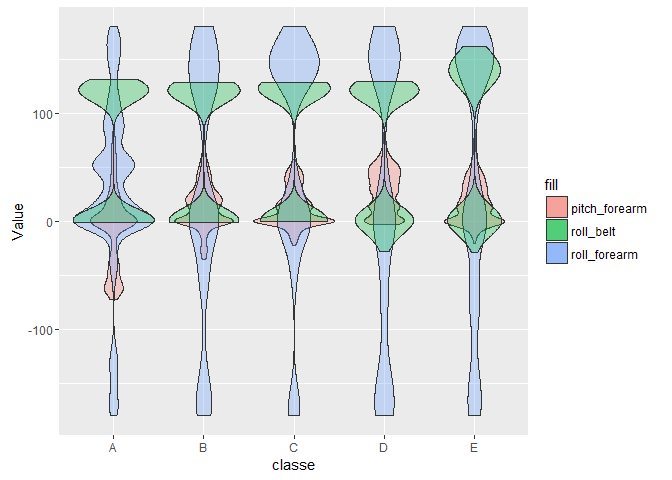

```r
ggplot(data=training2, aes(x=classe)) +
  geom_violin(aes(y = pitch_forearm, fill = 'pitch_forearm'), alpha = 0.3) +
  geom_violin(aes(y = roll_forearm, fill = 'roll_forearm'), alpha = 0.3) +
  geom_violin(aes(y = roll_belt, fill = 'roll_belt'), alpha = 0.3) +
  ylab('Value')
```

And we can see how effectively the figures are different and, depending on the classe, They have diferent intervals where they are bigger than the others.

## Model building

For the model, it can be used a combined prediction model using stacking. The models used for building the combined models will be random forest, linear discriminator analysis and generalized boosted regression modeling

```r
set.seed(2341)
# Calculate the three models and their predictions
model_rf <- train(classe ~ ., training2, method = 'rf')
model_lda <- train(classe ~ ., training2, method = 'lda')
model_gbm <- train(classe ~ ., training2, method = 'gbm')
pt_rf <- predict(model_rf)
pt_lda <- predict(model_lda)
pt_gbm <- predict(model_gbm)

# Combine them
pt_comb <- data.frame(classe = training2$classe, pt_rf, pt_lda, pt_gbm)
model_comb <- train(classe ~ ., pt_comb, method = 'rf')
```

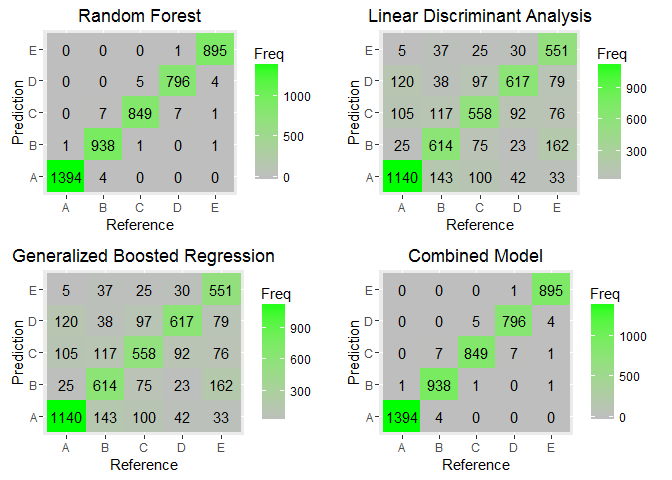

```r
# Predictions
pt_rf <- predict(model_rf, newdata = testing)
pt_lda <- predict(model_lda, newdata = testing)
pt_gbm <- predict(model_lda, newdata = testing)

pt_comb <- data.frame(pt_rf, pt_lda, pt_gbm)
prediction_testing <- predict(model_comb, newdata = pt_comb)

# Confusion matrixes
conf_rf <- confusionMatrix(pt_rf, testing$classe)
conf_lda <- confusionMatrix(pt_lda, testing$classe)
conf_gbm <- confusionMatrix(pt_gbm, testing$classe)
conf_comb <- confusionMatrix(prediction_testing, testing$classe)

# Plots
plot_rf <- ggplot(as.data.frame(conf_rf$table)) +
      geom_tile(aes(x=Reference, y=Prediction, fill=Freq)) +
      geom_text(aes(x=Reference, y=Prediction, label=Freq)) +
      scale_fill_gradient(low = 'grey', high='green') +
      ggtitle('Random Forest')

plot_lda <- ggplot(as.data.frame(conf_lda$table)) +
      geom_tile(aes(x=Reference, y=Prediction, fill=Freq)) +
      geom_text(aes(x=Reference, y=Prediction, label=Freq)) +
      scale_fill_gradient(low = 'grey', high='green') +
      ggtitle('Linear Discriminant Analysis')

plot_gbm <- ggplot(as.data.frame(conf_gbm$table)) +
      geom_tile(aes(x=Reference, y=Prediction, fill=Freq)) +
      geom_text(aes(x=Reference, y=Prediction, label=Freq)) +
      scale_fill_gradient(low = 'grey', high='green') +
      ggtitle('Generalized Boosted Regression')

plot_comb <- ggplot(as.data.frame(conf_comb$table)) +
      geom_tile(aes(x=Reference, y=Prediction, fill=Freq)) +
      geom_text(aes(x=Reference, y=Prediction, label=Freq)) +
      scale_fill_gradient(low = 'grey', high='green') +
      ggtitle('Combined Model')

grid.arrange(plot_rf, plot_lda, plot_gbm, plot_comb)
```

```r
# Finally add accuracy
accuracy_df <- data.frame(Method = c('Random Forest', 'Linear Discriminant Analysis', 'Generalized Boosted Regression', 'Combined Model'),
                          Accuracy = 100*c(conf_rf[['overall']]['Accuracy'], conf_lda[['overall']]['Accuracy'], conf_gbm[['overall']]['Accuracy'], conf_comb[['overall']]['Accuracy']))

kable(accuracy_df, col.names=c('Method', 'Accuracy (%)'))
```

| Method | Accuracy (%) |
| --- | --- |
| Random Forest | 99.34747 |
| Linear Discriminant Analysis | 70.96248 |
| Generalized Boosted Regression | 70.96248 |
| Combined Model | 99.34747 |

Finally, we can also check the confidence interval of the accuracy coming from the confusion matrix (using the combined model in this case). **The 95% confidence interval for the accuracy is [0.9908006, 0.9955326]**, so around 99% accuracy is expected for the combined model.

```r
kable(as.data.frame(conf_comb[['overall']]), col.names=c('Value'))
```

|  | Value |
| --- | --- |
| Accuracy | 0.9934747 |
| Kappa | 0.9917462 |
| AccuracyLower | 0.9908006 |
| AccuracyUpper | 0.9955326 |
| AccuracyNull | 0.2844617 |
| AccuracyPValue | 0.0000000 |
| McnemarPValue | NaN |

## Apply over test dataset

Finally, we can apply the model over the testing dataset, for which we do not have the observed classe. The predicted values for the 20 tests are:

```r
pt_rf <- predict(model_rf, newdata=plm.test_cases)
pt_lda <- predict(model_lda, newdata=plm.test_cases)
pt_gbm <- predict(model_gbm, newdata=plm.test_cases)

pt_comb <- data.frame(pt_rf, pt_lda, pt_gbm)

exercise_pred <- predict(model_comb, pt_comb)

kable(data.frame(problem_id = plm.test_cases$problem_id, predicted_classe = exercise_pred))
```

| problem_id | predicted_classe |
| --- | --- |
| 1 | B |
| 2 | A |
| 3 | B |
| 4 | A |
| 5 | A |
| 6 | E |
| 7 | D |
| 8 | B |
| 9 | A |
| 10 | A |
| 11 | B |
| 12 | C |
| 13 | B |
| 14 | A |
| 15 | E |
| 16 | E |
| 17 | A |
| 18 | B |
| 19 | B |
| 20 | B |